# NHANES 2017–2020: Health Insurance and Blood-Sugar Screening

Sensitivity analyses

Sujit Silas Armstrong, Janvi Bharucha, Amanda Millatt

June 11, 2026

# 1. Purpose

The primary analyses (outcome regression, IPW, doubly robust AIPW) identify the ATE of insurance on blood-sugar screening under **consistency**, **conditional exchangeability** given the DAG adjustment set, and **positivity**. These sensitivity analyses ask how fragile that conclusion is to violations of those assumptions and to analytic choices. Each check re-uses the **doubly robust (AIPW)** estimator as the workhorse, since it is the primary headline method.

```r
df <- read.csv(data_path, stringsAsFactors = FALSE)

df <- df %>%
  mutate(
    screened_bin = ifelse(screened == "Screened", 1, 0),
    treat        = ifelse(insured == "Insured", 1, 0),
    insured  = factor(insured, levels = c("Uninsured", "Insured")),
    sex      = factor(sex, levels = c("Male", "Female")),
    race_eth = factor(race_eth, levels = c("Non-Hispanic White", "Mexican American",
                                           "Other Hispanic", "Non-Hispanic Black",
                                           "Non-Hispanic Asian", "Other/Multi")),
    education = factor(education, levels = c("< High school", "High school / GED",
                                             "Some college", "College graduate")),
    marital  = factor(marital, levels = c("Married / partnered",
                                          "Widowed / divorced / separated",
                                          "Never married")),
    us_born  = factor(us_born, levels = c("Born in U.S.", "Born outside U.S.")),
    interview_lang = factor(interview_lang, levels = c("English", "Spanish")),
    gen_health   = factor(gen_health, levels = c("Excellent", "Very good",
                                                 "Good", "Fair", "Poor")),
    hypertension = factor(hypertension, levels = c("No", "Yes")),
    smoked_100   = factor(smoked_100,   levels = c("No", "Yes")),
    alcohol_ever = factor(alcohol_ever, levels = c("No", "Yes"))
  ) %>%
  filter(WTMECPRP > 0)

# primary adjustment set from the DAG (alcohol excluded for missingness)
primary_covs <- c("age", "sex", "race_eth", "education", "pir", "marital",
                  "us_born", "interview_lang", "bmi", "gen_health",
                  "hypertension", "smoked_100")
```

```r
# Reusable AIPW estimator. Returns the risk difference and risk ratio with
# design-based (delta-method) CIs. `ps_bounds` either truncates the propensity
# score (drop_outside = FALSE) or trims units outside the bounds
# (drop_outside = TRUE). Mirrors modeling/doubly_robust.Rmd.
aipw_estimate <- function(data, covs, ps_bounds = c(0, 1), drop_outside = FALSE) {
  d <- tidyr::drop_na(data, dplyr::all_of(c("treat", "screened_bin", covs)))
  d$sw <- d$WTMECPRP / mean(d$WTMECPRP)        # rescale weights for stable glm

  psf <- glm(reformulate(covs, "treat"), d, family = quasibinomial(), weights = sw)
  d$ps <- predict(psf, type = "response")

  if (drop_outside) {
    d <- d[d$ps >= ps_bounds[1] & d$ps <= ps_bounds[2], ]
  } else {
    d$ps <- pmin(pmax(d$ps, ps_bounds[1]), ps_bounds[2])
  }

  o1 <- glm(reformulate(covs, "screened_bin"), dplyr::filter(d, treat == 1),
            family = quasibinomial(), weights = sw)
  o0 <- glm(reformulate(covs, "screened_bin"), dplyr::filter(d, treat == 0),
            family = quasibinomial(), weights = sw)
  d$m1 <- predict(o1, d, type = "response")
  d$m0 <- predict(o0, d, type = "response")

  d$mu1 <- d$m1 + d$treat       / d$ps       * (d$screened_bin - d$m1)
  d$mu0 <- d$m0 + (1 - d$treat) / (1 - d$ps) * (d$screened_bin - d$m0)

  des <- svydesign(id = ~SDMVPSU, strata = ~SDMVSTRA, weights = ~WTMECPRP,
                   data = d, nest = TRUE)
  po <- svymean(~mu1 + mu0, des)
  rd <- svycontrast(po, quote(mu1 - mu0))
  rr <- svycontrast(po, quote(mu1 / mu0))

  data.frame(
    n     = nrow(d),
    rd    = as.numeric(coef(rd)),
    rd_se = as.numeric(SE(rd)),
    rd_lo = confint(rd)[1], rd_hi = confint(rd)[2],
    rr    = as.numeric(coef(rr)),
    rr_lo = confint(rr)[1], rr_hi = confint(rr)[2]
  )
}

# primary estimate for reference throughout
primary <- aipw_estimate(df, primary_covs)
round(primary, 4)
```

| n | rd | rd_se | rd_lo | rd_hi | rr | rr_lo | rr_hi |
| --- | --- | --- | --- | --- | --- | --- | --- |
| 5822 | 0.1869 | 0.0318 | 0.1245 | 0.2492 | 1.5016 | 1.2563 | 1.747 |

# 2. Unmeasured confounding (E-value)

How strong would an unmeasured confounder have to be — associated with *both* insurance and screening on the risk-ratio scale — to fully explain away the observed effect (and to push the confidence bound to the null)?

```r
ev <- EValue::evalues.RR(est = primary$rr, lo = primary$rr_lo, hi = primary$rr_hi)
ev
```

```
##             point    lower    upper
## RR       1.501628 1.256272 1.746985
## E-values 2.369533 1.823676       NA
```

An unmeasured confounder would need a risk ratio of **2.37** with both the exposure and the outcome (beyond the measured covariates) to explain away the point estimate, and **1.82** to move the lower confidence bound to the null.

# 3. Positivity: propensity trimming and truncation

The propensity overlap is thin at the top (adults 65+ are ~98% insured via Medicare). We re-estimate the ATE after (a) **truncating** the propensity score to progressively tighter bounds and (b) **trimming** the sample to the region of common support, and check whether the conclusion is stable.

```r
positivity <- dplyr::bind_rows(
  cbind(spec = "No trimming",            aipw_estimate(df, primary_covs)),
  cbind(spec = "Truncate PS [0.05,0.95]", aipw_estimate(df, primary_covs, c(0.05, 0.95))),
  cbind(spec = "Truncate PS [0.10,0.90]", aipw_estimate(df, primary_covs, c(0.10, 0.90))),
  cbind(spec = "Trim to PS [0.05,0.95]",  aipw_estimate(df, primary_covs, c(0.05, 0.95),
                                                        drop_outside = TRUE))
)
positivity %>%
  transmute(spec, n,
            risk_difference = round(rd, 4),
            CI = sprintf("(%.3f, %.3f)", rd_lo, rd_hi))
```

| spec | n | risk_difference | CI |
| --- | --- | --- | --- |
| No trimming | 5822 | 0.1869 | (0.124, 0.249) |
| Truncate PS [0.05,0.95] | 5822 | 0.1606 | (0.124, 0.197) |
| Truncate PS [0.10,0.90] | 5822 | 0.1597 | (0.131, 0.189) |
| Trim to PS [0.05,0.95] | 4059 | 0.1499 | (0.087, 0.212) |

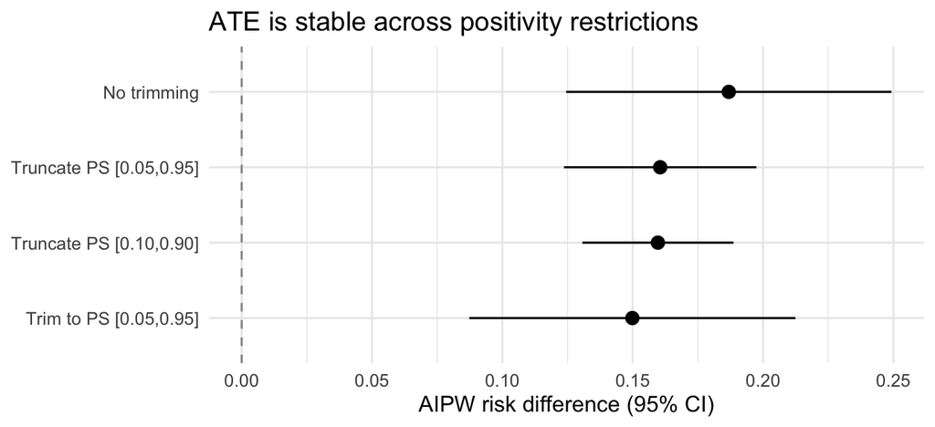

# 4. Alternative adjustment sets

```r
sets <- list(
  "Primary (12 covariates)" = primary_covs,
  "+ alcohol_ever"          = c(primary_covs, "alcohol_ever"),
  "Demographic / SES only"  = c("age", "sex", "race_eth", "education", "pir",
                                "marital", "us_born", "interview_lang"),
  "Minimal (age, sex, race, educ, income)" =
                              c("age", "sex", "race_eth", "education", "pir")
)

adjustment <- dplyr::bind_rows(lapply(names(sets), function(nm) {
  cbind(adjustment_set = nm, aipw_estimate(df, sets[[nm]]))
}))
adjustment %>%
  transmute(adjustment_set, n,
            risk_difference = round(rd, 4),
            CI = sprintf("(%.3f, %.3f)", rd_lo, rd_hi))
```

| adjustment_set | n | risk_difference | CI |
| --- | --- | --- | --- |
| Primary (12 covariates) | 5822 | 0.1869 | (0.124, 0.249) |
| + alcohol_ever | 5512 | 0.1889 | (0.124, 0.254) |
| Demographic / SES only | 5933 | 0.1692 | (0.103, 0.235) |
| Minimal (age, sex, race, educ, income) | 5934 | 0.1502 | (0.090, 0.210) |

# 5. Missing-data handling: complete case vs. multiple imputation

The primary analyses use complete cases (`pir` and `alcohol_ever` drive most of the loss). Here we multiply-impute the covariates, re-estimate the AIPW risk difference within each completed dataset, and pool with Rubin’s rules — checking whether complete-case analysis materially biases the estimate.

```r
set.seed(235)

# impute the covariates + treatment/outcome; keep design vars as-is
impute_vars <- c("treat", "screened_bin", primary_covs)
design_vars <- c("SDMVPSU", "SDMVSTRA", "WTMECPRP")

mids <- mice(df[, c(impute_vars, design_vars)],
             m = 5, maxit = 5, printFlag = FALSE)

# AIPW risk difference + SE in each completed dataset
mi_fits <- lapply(1:mids$m, function(i) {
  d_i <- complete(mids, i)
  aipw_estimate(d_i, primary_covs)[, c("rd", "rd_se")]
})
mi_mat <- do.call(rbind, mi_fits)
```

```r
# Rubin's rules
m       <- nrow(mi_mat)
qbar    <- mean(mi_mat$rd)                       # pooled point estimate
ubar    <- mean(mi_mat$rd_se^2)                  # within-imputation variance
b       <- var(mi_mat$rd)                        # between-imputation variance
T_var   <- ubar + (1 + 1 / m) * b               # total variance
se_pool <- sqrt(T_var)

data.frame(
  method = c("Complete case (primary)", "Multiple imputation (m=5, pooled)"),
  risk_difference = round(c(primary$rd, qbar), 4),
  CI = c(sprintf("(%.3f, %.3f)", primary$rd_lo, primary$rd_hi),
         sprintf("(%.3f, %.3f)", qbar - 1.96 * se_pool, qbar + 1.96 * se_pool))
)
```

| method | risk_difference | CI |
| --- | --- | --- |
| Complete case (primary) | 0.1869 | (0.124, 0.249) |
| Multiple imputation (m=5, pooled) | 0.1615 | (0.102, 0.221) |

# 6. Summary

```
## Primary AIPW risk difference:  0.187 (95% CI 0.124, 0.249)
```

```
##
## The effect direction and rough magnitude should persist across all four
##  checks above; large movement in any one flags the assumption the headline
##  estimate is most fragile to.
```